# PRÁCTICA 4A: REPORTE ESCRITO. EXPERIMENTOS Y ANÁLISIS DE ALGORITMOS DE BÚSQUEDA POR COMPARACIÓN.

PROFESOR: DR. ERIC SADIT TÉLLEZ AVILA

ESTUDIANTE: EDGAR SANTIAGO GONZALEZ MARTINEZ

# Introducción

Esta actividad implementa y compara cinco algoritmos de búsqueda en el modelo de comparación: búsqueda binaria (acotada), B₀ (secuencial), B₁ (no acotada por *doubling*), B₂ (no acotada por *double-doubling*) y la estructura SkipList. El análisis se realiza sobre el dataset `p016`, `p032`, `p064`, `p128`, `p256`, `p512` de la Unidad 3 y utiliza como conjunto de consultas los archivos `cons1`, `cons2`, `cons3` y `cons4`.

Para cada pareja dataset con los de consulta se mide el número total de búsquedas ejecutadas, el promedio de comparaciones por consulta, el tiempo total acumulado y el tiempo promedio por consulta. El objetivo es contrastar la eficiencia algorítmica y el rendimiento práctico, observando cómo varían según la distribución de los datos y el patrón de consultas.

# Conexión de Google Drive con Google Colab

Como primer procedimiento, se conecta Google Drive con Google Colab para poder acceder a los archivos almacenados en la nube.

La instrucción `from google.colab import drive` permite importar el módulo `drive`, el cual posibilita que Colab interactúe con Google Drive. El comando `drive.mount('/content/drive')` monta Google Drive en la carpeta `/content/drive`.

```python
# Cargar Google Drive
from google.colab import drive
drive.mount('/content/drive')
```

# Paqueterías usadas

En esta parte **se prepara el entorno** con `os` y `json` el cuaderno accede al sistema de archivos y carga estructuras en formato JSON que contienen listas de posteo y consultas.

`numpy` para manipular arreglos numéricos, mientras que `itertools.chain` facilita aplanar listas anidadas provenientes de distintas claves dentro de un mismo JSON.

Para medir rendimiento, `time` y `random` controla la aleatoriedad necesaria en la estructura probabilística SkipList.

Finalmente, `pandas` organiza los resultados en DataFrames para resumir y exportar, y `matplotlib.pyplot` permite generar, en celdas posteriores, las visualizaciones comparativas de comparaciones y tiempos.

```python
import os, json, numpy as np
from itertools import chain
import time, random, numpy as np, pandas as pd
import matplotlib.pyplot as plt
```

# Extracción de archivos desde Google Drive

La función `vec_global(path, dtype)` carga un archivo JSON y extrae todos los números que encuentre. Si la raíz es un `dict`, concatena únicamente los valores que sean listas o tuplas; si la estructura está anidada, recorre recursivamente y rinde cada número. Convierte enteros y flotantes a `int` y construye un `np.ndarray` con el `dtype` indicado.

En la sección “Listas de posteo” define la ruta base `RUTA_P` y crea seis arreglos (`p016`, `p032`, `p064`, `p128`, `p256`, `p512`) leyendo cada JSON correspondiente. De forma análoga, en “Archivos de consultas” define `RUTA_C` y carga las consultas `cons1`–`cons4`. Con esto se dispone de dos grupos de datos: **datasets** donde se buscará y **consultas** que se aplicarán a cada dataset.

```python
def vec_global(path, dtype=np.int64):
    with open(path, encoding="utf-8") as f:
        d = json.load(f)
    if isinstance(d, dict):
        return np.fromiter(
            chain.from_iterable(v for v in d.values() if isinstance(v, (list, tuple))),
            dtype=dtype,
        )
    def walk(x):
        if isinstance(x, dict):
            for v in x.values(): yield from walk(v)
        elif isinstance(x, (list, tuple, set)):
            for v in x: yield from walk(v)
        elif isinstance(x, (np.integer, int)): yield int(x)
        elif isinstance(x, (np.floating, float)): yield int(x)
    return np.fromiter(walk(d), dtype=dtype)

# Listas de posteo (Unidad 3)
RUTA_P = "/content/drive/MyDrive/MCDI/3A_AdA/listas-posteo-con-perturbaciones"
p016 = vec_global(f"{RUTA_P}/listas-posteo-con-perturbaciones-p=016.json")
p032 = vec_global(f"{RUTA_P}/listas-posteo-con-perturbaciones-p=032.json")
p064 = vec_global(f"{RUTA_P}/listas-posteo-con-perturbaciones-p=064.json")
p128 = vec_global(f"{RUTA_P}/listas-posteo-con-perturbaciones-p=128.json")
p256 = vec_global(f"{RUTA_P}/listas-posteo-con-perturbaciones-p=256.json")
p512 = vec_global(f"{RUTA_P}/listas-posteo-con-perturbaciones-p=512.json")

# Archivos de consultas
RUTA_C = "/content/drive/MyDrive/MCDI/4A_AdA/Consultas-20251029"
cons1 = vec_global(f"{RUTA_C}/consultas-1-listas-posteo.json")
cons2 = vec_global(f"{RUTA_C}/consultas-2-listas-posteo.json")
cons3 = vec_global(f"{RUTA_C}/consultas-3-listas-posteo.json")
cons4 = vec_global(f"{RUTA_C}/consultas-4-listas-posteo.json")

# Vista de longuitud
for name, arr in [("p016",p016),("p032",p032),("p064",p064),("p128",p128),("p256",p256),("p512",p512),
                  ("cons1",cons1),("cons2",cons2),("cons3",cons3),("cons4",cons4)]:
    print(f"{name}: n={arr.size}")
```

```
p016: n=191852
p032: n=191852
p064: n=191852
p128: n=191852
p256: n=191852
p512: n=191852
cons1: n=10000
cons2: n=10000
cons3: n=10000
cons4: n=10000
```

Tras el análisis exploratorio, se comprobó que las listas de posteo (`p016`, `p032`, `p064`, `p128`, `p256`, `p512`) contienen el mismo multiconjunto de valores; solo difieren con el grado de desorden. Al **ordenarlas, todas resultan idénticas**.

Dado que los algoritmos de búsqueda sobre arreglos requieren datos ordenados, el “nivel de desorden” inicial no introduce diferencias en la evaluación. Por esta razon, en esta actividad se utiliza **una sola lista representativa** (`p016`) para comparar el desempeño frente a los distintos archivos de consultas.

# Algoritmos de búsqueda

## Parámetros de desempeño

La clase `CmpCounter` instrumenta el modelo de comparación: cada vez que se evalúa una relación (`<` o `<=`) mediante sus métodos `lt` y `le`, incrementa el contador interno `count`. De este modo, el cuaderno mide cuántas comparaciones de clave realiza un algoritmo por consulta, aislando ese costo lógico de otros costos.

La función `timed` cronometra la ejecución de una llamada con `time.perf_counter()`. Devuelve una tupla con el resultado de la función invocada y la duración en segundos, lo que permite reportar tanto el rendimiento teórico como el rendimiento práctico para cada algoritmo y conjunto de consultas.

```python
class CmpCounter:
    def __init__(self): self.count = 0
    def lt(self, a, b): self.count += 1; return a < b
    def le(self, a, b): self.count += 1; return a <= b

def timed(fn, *args, **kwargs):
    t0 = time.perf_counter()
    out = fn(*args, **kwargs)
    t1 = time.perf_counter()
    return out, (t1 - t0)
```

## Binaria

Implementa la variante lower_bound de la búsqueda **binaria acotada**: dada un arreglo ordenado y un rango `[lo, hi)`, mantiene ese intervalo, calcula `mid = (lo + hi) // 2` y, si `A[mid] < x`, avanza `lo = mid + 1`; en caso contrario, reduce `hi = mid`. Al terminar (`lo == hi`) devuelve la **posición de inserción** `i = min { j : A[j] ≥ x }`. La instrumentación `CmpCounter` cuenta las comparaciones; la función retorna `(posición, comparaciones)`. En el modelo de comparación, el costo es **O(log n)** (Cormen, Leiserson, Rivest, & Stein, 2009).

```python
def binary_search_lb(A, x, lo=0, hi=None, cmp=None):
    if hi is None: hi = len(A)
    if cmp is None: cmp = CmpCounter()
    while lo < hi:
        mid = (lo + hi) // 2
        if cmp.lt(A[mid], x):
            lo = mid + 1
        else:
            hi = mid
    return lo, cmp.count
```

## B0: secuencial

La función `search_B0` realiza una **búsqueda secuencial** tipo lower_bound: parte en `sp` y avanza mientras `A[i] < x`, contando comparaciones con `CmpCounter`, hasta detenerse en el **primer índice** donde `A[i] ≥ x`. En el modelo de comparación, su costo es **lineal** en la distancia recorrida desde `sp` (en el peor de los casos, $O(n)$), por lo que resulta ventajosa cuando la posición de inserción está **cerca** del punto de partida y desfavorable cuando está **lejos** (Knuth, 1998).

```python
def search_B0(A, x, sp=0, cmp=None):
    if cmp is None: cmp = CmpCounter()
    i, n = sp, len(A)
    while i < n and cmp.lt(A[i], x):
        i += 1
    return i, cmp.count
```

## B1: *doubling* + binaria

La función `search_B1` implementa una **búsqueda no acotada por *doubling*** (exponential search). Desde `sp`, duplica el salto (`i = 1, 2, 4, …`) mientras `A[sp+i] < x` para acotar con rapidez un intervalo $[lo,\,hi)$ que contiene la posición de inserción; después aplica una **binaria restringida** (`binary_search_lb`) en ese rango. El contador `CmpCounter` registra las comparaciones de ambas fases y la rutina devuelve `(posición, comparaciones)`. En arreglos ordenados ascendentemente, el costo total es $O(\log p)$, con $p$ la distancia desde `sp` hasta la posición buscada, lo que la vuelve favorable cuando el objetivo está **alejado** del punto de partida (Cormen, Leiserson, Rivest, & Stein, 2009).

```python
def search_B1(A, x, sp=0):
    n = len(A)
    cmp = CmpCounter()
    i, p = 1, 0
    while sp + i < n and cmp.lt(A[sp + i], x):
        p = i
        i <<= 1
    lo, hi = sp + p, min(n, sp + i + 1)
    pos, _ = binary_search_lb(A, x, lo, hi, cmp=cmp)
    return pos, cmp.count
```

## B2: no acotada con crecimiento doble-exponencial

La función `search_B2` realiza una búsqueda no acotada que acota primero el rango mediante saltos **doble-exponenciales** (`pt = 2^{2^t}`: 2, 4, 16, 256, …) partiendo de `sp`. Mientras `A[sp+pt-1] < x`, incrementa `t`, actualiza `prev` y amplía el salto hasta encerrar la posición buscada en el intervalo $[lo,\,hi) = [\,sp+\texttt{prev},\ \min(n,\,sp+\texttt{pt})\,)$. Sobre ese subrango aplica luego `binary_search_lb` para obtener la **posición de inserción** (primer índice con $A[i]\ge x$). El contador `CmpCounter` acumula las comparaciones de ambas fases y la rutina retorna `(posición, comparaciones)`. En arreglos ordenados, la expansión cuesta $O(\log\log p)$ pasos y la binaria $O(\log p)$ comparaciones, de modo que el costo total es $O(\log p)$, reduciendo la sobrecarga de la fase de acotamiento frente al *doubling* clásico cuando la clave está muy alejada de `sp` (Bentley & Yao, 1976).

```python
def search_B2(A, x, sp=0):
    n = len(A)
    cmp = CmpCounter()
    t, prev, pt = 0, 0, 2  # 2,4,16,256,...
    while sp + pt - 1 < n and cmp.lt(A[sp + pt - 1], x):
        prev = pt
        t += 1
        pt = 2 ** (2 ** t)
        if pt <= prev: pt = prev + 1
    lo, hi = sp + prev, min(n, sp + pt)
    pos, _ = binary_search_lb(A, x, lo, hi, cmp=cmp)
    return pos, cmp.count
```

## SkipList

La implementación define una **SkipList** probabilística con nodos `SkipNode` que almacenan una `key` y un arreglo de punteros `forward` a distintos niveles. La clase `SkipList` mantiene un nodo cabecera (`header`), el nivel actual de la estructura (`level`) y el parámetro de probabilidad `p` que controla la altura esperada de los nodos (distribución geométrica). El método `_rand_level` genera aleatoriamente el nivel de un nuevo nodo; `insert` recorre de arriba hacia abajo registrando en `update` el último nodo visitado en cada nivel, ajusta `self.level` si el nuevo nodo es más alto, y enlaza el nodo en todos sus niveles, conservando duplicados como nodos separados. El método `lower_bound(x)` realiza una búsqueda descendente: avanza horizontalmente en cada nivel mientras la clave siguiente sea `< x`, desciende de nivel cuando ya no puede avanzar, y finalmente retorna la **primera clave ≥ x** (o `None` si no existe). La función auxiliar `build_skiplist` construye la estructura insertando todos los elementos de `A`. Con esta instrumentación, las comparaciones se cuentan mediante `CmpCounter`. En expectativa, la SkipList ofrece **búsqueda e inserción en $O(\log n)$**, con constantes bajas y balanceo probabilístico controlado por `p` (Pugh, 1990).

```python
class SkipNode:
    __slots__ = ("key", "forward")
    def __init__(self, key, level):
        self.key = key
        self.forward = [None]*(level+1)

class SkipList:
    def __init__(self, p=0.5, max_level=32, seed=12345):
        self.p = p; self.max_level = max_level
        random.seed(seed)
        self.header = SkipNode(None, max_level)
        self.level = 0
    def _rand_level(self):
        lvl = 0
        while random.random() < self.p and lvl < self.max_level:
            lvl += 1
        return lvl
    def insert(self, key):
        update = [None]*(self.max_level+1)
        x = self.header
        for i in range(self.level, -1, -1):
            while x.forward[i] is not None and x.forward[i].key < key:
                x = x.forward[i]
            update[i] = x
        lvl = self._rand_level()
        if lvl > self.level:
            for i in range(self.level+1, lvl+1):
                update[i] = self.header
            self.level = lvl
        node = SkipNode(int(key), lvl)
        for i in range(lvl+1):
            node.forward[i] = update[i].forward[i]
            update[i].forward[i] = node
    def lower_bound(self, x, cmp=None):
        if cmp is None: cmp = CmpCounter()
        cur = self.header
        for i in range(self.level, -1, -1):
            while cur.forward[i] is not None and cmp.lt(cur.forward[i].key, x):
                cur = cur.forward[i]
        cur = cur.forward[0]
        return (cur.key if cur is not None else None), cmp.count

def build_skiplist(A, seed=12345, p=0.5, max_level=32):
    sl = SkipList(p=p, max_level=max_level, seed=seed)
    for v in A: sl.insert(int(v))
    return sl
```

# Comparaciones

La función `EvalAlgs` evalúa, sobre un arreglo ya ordenado, el desempeño de los algoritmos de búsqueda definidos (Binaria, B0, B1, B2 y, opcionalmente, SkipList). Si `use_skiplist` es verdadero, construye una sola SkipList y la reutiliza en todas las consultas. Para cada algoritmo, recorre las claves de `qs`, mide el **tiempo** por consulta en **segundos** y acumula el **número de comparaciones** reportado por la instrumentación interna (`CmpCounter`). Con esos datos calcula tres indicadores agregados: el **promedio de comparaciones por consulta** (`prom_comp/consul`), el **tiempo total** en segundos (`t_total_s`) y el **tiempo promedio por consulta** en segundos (`t_prom_s`). El resultado se devuelve como un `DataFrame` ordenado por el nombre del algoritmo.

La función `EvalData` prepara la pareja *dataset–consulta* para el experimento. Primero **ordena** el arreglo base para garantizar la semántica de `lower_bound` en Binaria/B0/B1/B2; después, permite **muestrear** las consultas si se define `sample_k`. Luego delega en `EvalAlgs` el levantamiento de métricas y añade las columnas de contexto (`dataset`, `consulta`) antes de devolver un `DataFrame` con las columnas clave. En síntesis, `EvalData` organiza los datos y `EvalAlgs` computa los indicadores comparables de modelo de comparación y rendimiento práctico.

```python
def EvalAlgs(A_sorted, qs, seed=123, use_skiplist=True):
    if use_skiplist:
        sl = build_skiplist(A_sorted, seed=seed)
    algos = {
        "Binaria": lambda arr, x: binary_search_lb(arr, x),
        "B0":      lambda arr, x: search_B0(arr, x),
        "B1":      lambda arr, x: search_B1(arr, x),
        "B2":      lambda arr, x: search_B2(arr, x),
    }
    if use_skiplist:
        algos["skiplist"] = lambda arr, x: sl.lower_bound(x)

    rows = []
    for name, fn in algos.items():
        comps, times = [], []
        for x in qs:
            (pos, c), t = timed(fn, A_sorted, x)
            comps.append(c); times.append(t)
        rows.append({
            "algoritmo":        name,
            "consultas":        int(len(qs)),
            "prom_comp/consul": float(np.mean(comps)),
            "t_total_s":        float(np.sum(times)),
            "t_prom_s":         float(np.mean(times)),
        })
    return pd.DataFrame(rows).sort_values("algoritmo").reset_index(drop=True)

def EvalData(dataset_arr, consultas_arr, dataset_name="p=016", consulta_name="cons1",
             sample_k=None, seed=42, use_skiplist=True):
    rng = np.random.default_rng(seed)
    A = np.sort(dataset_arr, kind="stable")
    qs = consultas_arr
    if (sample_k is not None) and (len(qs) > sample_k):
        idx = rng.choice(len(qs), size=sample_k, replace=False)
        qs = qs[idx]

    df = EvalAlgs(A, qs, seed=seed, use_skiplist=use_skiplist)  # <— renombrada
    df.insert(0, "dataset", dataset_name)
    df.insert(1, "consulta", consulta_name)

    cols = ["dataset","consulta","algoritmo","consultas","prom_comp/consul","t_total_s","t_prom_s"]
    out = df[cols].sort_values("algoritmo").reset_index(drop=True)
    display(out)
    return out
```

# Resultados

## Archivo p=016 con el archivo de consulta *cons1*

Se ejecutaron 10,000 consultas (tamaño de *cons1*). En comparaciones promedio por consulta, el orden observado es: **B1**, **B2**, **Binaria**, **SkipList** y **B0**.

En **tiempo**, el comportamiento es consistente con la teoría: B1 y B2 usan menos comparaciones y también lideran en tiempo; SkipList queda en un nivel intermedio y Binaria es muy estable, aunque ligeramente más lenta. B0 resulta la peor opción.

```python
results_p016_cons1 = EvalData(p016, cons1, dataset_name="p=016", consulta_name="cons1", seed=42, use_skiplist=True)
```

|  | dataset | consulta | algoritmo | consultas | prom_comp/consul | t_total_s | t_prom_s |
| --- | --- | --- | --- | --- | --- | --- | --- |
| 0 | p=016 | cons1 | B0 | 10000 | 29.5284 | 0.045016 | 0.000005 |
| 1 | p=016 | cons1 | B1 | 10000 | 9.7896 | 0.023589 | 0.000002 |
| 2 | p=016 | cons1 | B2 | 10000 | 10.1000 | 0.026562 | 0.000003 |
| 3 | p=016 | cons1 | Binaria | 10000 | 17.6297 | 0.036202 | 0.000004 |
| 4 | p=016 | cons1 | skiplist | 10000 | 21.9627 | 0.030156 | 0.000003 |

## Archivo p=016 con el archivo de consulta *cons2*

En comparaciones promedio por consulta, el orden observado es: **Binaria**, **B1**, **B2**, **SkipList** y **B0**.

En tiempo, el patrón cambia: **SkipList** obtiene el mejor tiempo total, seguida de **Binaria**, **B1** y **B2**. **B0** queda muy por detrás. Esto refuerza que más comparaciones no siempre implican mayor tiempo: aunque **SkipList** compara más que **Binaria**, su bucle y saltos por niveles le dan mejor tiempo para las consultas.

```python
results_p016_cons2 = EvalData(p016, cons2, dataset_name="p=016", consulta_name="cons2", seed=42, use_skiplist=True)
```

|  | dataset | consulta | algoritmo | consultas | prom_comp/consul | t_total_s | t_prom_s |
| --- | --- | --- | --- | --- | --- | --- | --- |
| 0 | p=016 | cons2 | B0 | 10000 | 503.5401 | 0.773648 | 0.000077 |
| 1 | p=016 | cons2 | B1 | 10000 | 17.9671 | 0.040135 | 0.000004 |
| 2 | p=016 | cons2 | B2 | 10000 | 18.5620 | 0.045553 | 0.000005 |
| 3 | p=016 | cons2 | Binaria | 10000 | 17.6827 | 0.037758 | 0.000004 |
| 4 | p=016 | cons2 | skiplist | 10000 | 25.7413 | 0.035895 | 0.000004 |

## Archivo p=016 con el archivo de consulta cons3

En comparaciones promedio por consulta, el orden observado es: **Binaria**, **B2**, **B1**, **SkipList** y **B0**.

En tiempo, gana **Binaria**, seguida de **B2**, **B1** y **SkipList**; **B0** queda muy por detrás. Con este patrón de consultas, **Binaria** domina en ambas métricas; **B2** supera a **B1** y **SkipList** no aporta ventaja en tiempo.

```python
results_p016_cons3 = EvalData(p016, cons3, dataset_name="p=016", consulta_name="cons3", seed=42, use_skiplist=True)
```

|  | dataset | consulta | algoritmo | consultas | prom_comp/consul | t_total_s | t_prom_s |
| --- | --- | --- | --- | --- | --- | --- | --- |
| 0 | p=016 | cons3 | B0 | 10000 | 7575.7269 | 14.020803 | 0.001402 |
| 1 | p=016 | cons3 | B1 | 10000 | 25.8497 | 0.056442 | 0.000006 |
| 2 | p=016 | cons3 | B2 | 10000 | 20.8490 | 0.050681 | 0.000005 |
| 3 | p=016 | cons3 | Binaria | 10000 | 17.6385 | 0.039188 | 0.000004 |
| 4 | p=016 | cons3 | skiplist | 10000 | 29.8543 | 0.057508 | 0.000006 |

## Archivo p=016 con el archivo de consulta cons4

En comparaciones promedio por consulta, el orden observado es: **Binaria**, **B2**, **B1**, **SkipList** y **B0**.

En **tiempo**, domina **Binaria**, seguida de **B2** y **B1**; **SkipList** queda atrás y **B0** es claramente inviable. En este patrón, binaria es la mejor tanto en comparaciones como en tiempo, B2 supera a B1 y la SkipList no ofrece ventaja.

```python
results_p016_cons4 = EvalData(p016, cons4, dataset_name="p=016", consulta_name="cons4", seed=42, use_skiplist=True)
```

|  | dataset | consulta | algoritmo | consultas | prom_comp/consul | t_total_s | t_prom_s |
| --- | --- | --- | --- | --- | --- | --- | --- |
| 0 | p=016 | cons4 | B0 | 10000 | 98816.2924 | 171.919109 | 0.017192 |
| 1 | p=016 | cons4 | B1 | 10000 | 32.7487 | 0.074762 | 0.000007 |
| 2 | p=016 | cons4 | B2 | 10000 | 21.6608 | 0.057602 | 0.000006 |
| 3 | p=016 | cons4 | Binaria | 10000 | 17.6355 | 0.043827 | 0.000004 |
| 4 | p=016 | cons4 | skiplist | 10000 | 33.6267 | 0.107717 | 0.000011 |

```python
pd_global = pd.concat([results_p016_cons1, results_p016_cons2, results_p016_cons3, results_p016_cons4],ignore_index=True)
#display(pd_global)
```

En los gráficos se visualizan los mismos resultados descritos en las tablas, comparando el tiempo promedio y las comparaciones promedio por consulta. Se agrupan por tipo de algoritmo para mantener la misma escala y evitar distorsiones cuando algún método consume mucho más tiempo o comparaciones.

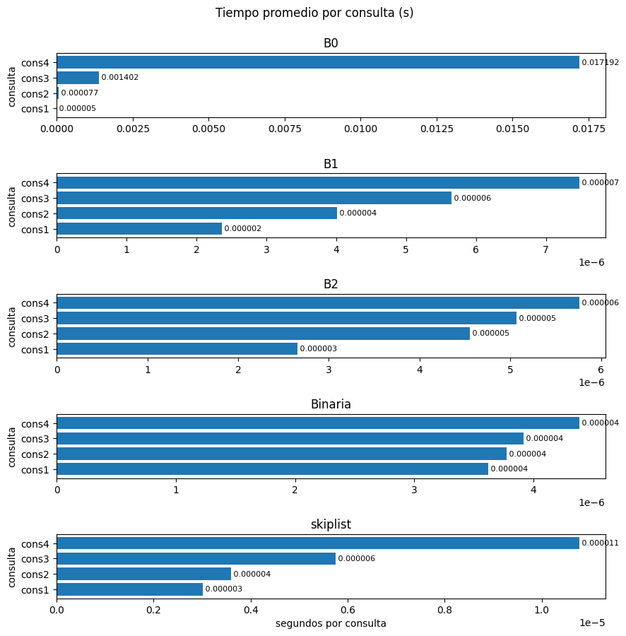

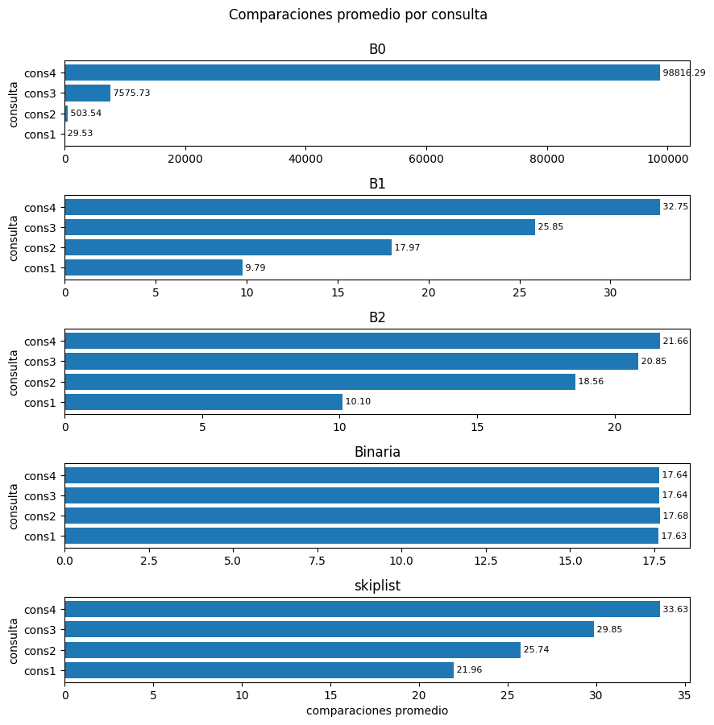

```python
def plot_results(df, value_col, suptitle, xlabel, fmt="{:.6f}"):
    algos = list(df["algoritmo"].drop_duplicates())
    fig, axes = plt.subplots(len(algos), 1, figsize=(9, 1.8*len(algos)), sharex=False)
    if len(algos) == 1:
        axes = [axes]
    for ax, algo in zip(axes, algos):
        sub = df[df["algoritmo"] == algo]
        cons_order = list(sub["consulta"].drop_duplicates())
        vals = sub.set_index("consulta")[value_col].reindex(cons_order)
        ax.barh(cons_order, vals.values)
        for i, v in enumerate(vals.values):
            if pd.notna(v):
                ax.text(v, i, f" {fmt.format(v)}", va="center", ha="left", fontsize=8)
        ax.set_title(algo)
        ax.set_ylabel("consulta")
    axes[-1].set_xlabel(xlabel)
    fig.suptitle(suptitle, y=0.995, fontsize=12)
    plt.tight_layout()
    plt.show()

# 1) Tiempo promedio (s)
plot_results(
    pd_global,
    value_col="t_prom_s",
    suptitle="Tiempo promedio por consulta (s)",
    xlabel="segundos por consulta",
    fmt="{:.6f}"
)

# 2) Comparaciones promedio por consulta
plot_results(
    pd_global,
    value_col="prom_comp/consul",
    suptitle="Comparaciones promedio por consulta",
    xlabel="comparaciones promedio",
    fmt="{:.2f}"
)
```

# Conclusión

En conjunto, los resultados muestran que, con un arreglo estático y ordenado, la **búsqueda binaria** es el mejor punto de partida: ofrece tiempos muy bajos y estables, siendo con frecuencia la más rápida.

Las variantes no acotadas confirman la teoría: **B1** y **B2** crecen de forma logarítmica con la distancia a la posición objetivo; además, **B2** suele superar a **B1** cuando las claves están lejos gracias a una acotación más agresiva. La **SkipList** puede competir en tiempo e incluso ganar en ciertos patrones, aunque no reduce comparaciones frente a binaria y añade sobrecarga estructural. **B0** solo es razonable si la clave está muy próxima al punto de partida; de lo contrario, su costo se dispara.

## Referencias

Bentley, J. L., & Yao, A. C.-C. (1976). An almost optimal algorithm for unbounded searching. *Information Processing Letters, 5*(3), 82–87.

Bentley, J. L., & McGeoch, C. C. (1985). Amortized analyses of self-organizing sequential search heuristics. *Communications of the ACM, 28*(4), 404–411.

Cormen, T. H., Leiserson, C. E., Rivest, R. L., & Stein, C. (2009). *Introduction to algorithms* (3rd ed.). MIT Press.

Knuth, D. E. (1998). *The art of computer programming, Volume 3: Sorting and searching* (2nd ed.). Addison-Wesley.

Pugh, W. (1990). Skip lists: A probabilistic alternative to balanced trees. *Communications of the ACM, 33*(6), 668–676.

Sadit. (s. f.). 5. Algoritmos de búsqueda en el modelo de comparación. En *Curso Introductorio al Análisis de Algoritmos con Julia*. Recuperado de https://sadit.github.io/ALGO-IR/cap5-busqueda.html